# **Detecting Malaria Parasites in Blood Smear Microscopy**

### Compiling Model 1

Building a model only describes its *shape*. **Compiling** attaches the three pieces a model needs in order to learn:

1. **Optimizer** — the algorithm that updates the weights using gradients (e.g. Adam, SGD).
2. **Loss function** — the scalar quantity the optimizer is trying to minimise.
3. **Metrics** — quantities reported during training/evaluation but not optimised directly (e.g. accuracy).

Keeping these *identical* across Model 1 and the Base Model is a deliberate experimental choice — see the comment in the next cell.

```python
# ──────────────────────────────────────────────────────────────────────
# Compile Model 1 with the SAME training configuration as the
# Base Model so the only variable between the two experiments is
# the architecture itself. This is a controlled comparison.
# ──────────────────────────────────────────────────────────────────────
# Same optimiser / loss / metric as the Base Model — so any accuracy
# difference isolates the architectural change rather than confounding it
# with a training-configuration change.
#
# - `optimizer='adam'` uses Adam with default learning rate 1e-3.
#   Adam is a sensible default that adapts the LR per parameter and
#   usually "just works" without manual tuning.
# - `loss='categorical_crossentropy'` is the standard loss for
#   multi-class classification with one-hot encoded labels.
# - `metrics=['accuracy']` reports the percentage of correct
#   predictions during training and evaluation.
model1.compile(optimizer='adam', loss='categorical_crossentropy', metrics=['accuracy'])
```

### Callbacks for Model 1

**Callbacks** are objects that Keras calls at specific points during training (start of epoch, end of batch, etc.) to perform side-effect tasks like logging, saving checkpoints, or *adjusting training* in response to what is happening.

Two callbacks dominate practical training:

- **`EarlyStopping`** — monitors a validation metric and halts training when it stops improving for `patience` consecutive epochs. Prevents wasting compute on epochs that no longer help, and (with `restore_best_weights=True`) hands back the *best* weights it saw, not the final ones.
- **`ReduceLROnPlateau`** — when the monitored metric plateaus, shrinks the learning rate by `factor`. The intuition is that you are now in a narrower part of the loss landscape and need smaller steps to keep descending.

Defining these *next to the model* (not inside the build function) keeps the architecture and training-loop concerns separable.

```python
# ──────────────────────────────────────────────────────────────────────
# Define the callback list that will be passed to model1.fit().
# Each callback hooks into specific phases of training and adjusts
# the run automatically — no manual intervention required.
# ──────────────────────────────────────────────────────────────────────
# Define Model 1's callbacks alongside the model so EarlyStopping / LR reduction
# are paired with the experiment they belong to.
callbacks1 = [
    # EarlyStopping watches `val_loss`. If it does not improve for 5
    # consecutive epochs (patience=5), training halts. Then
    # `restore_best_weights=True` rewinds the model's weights to the
    # epoch that achieved the lowest val_loss — so we keep the best
    # version of the model, not the last one trained.
    EarlyStopping(monitor='val_loss', patience=5, restore_best_weights=True),
    # ReduceLROnPlateau halves the learning rate (factor=0.5) when
    # val_loss plateaus for 2 epochs. The lower bound (min_lr=1e-6)
    # prevents the LR from collapsing to effectively zero.
    ReduceLROnPlateau(monitor='val_loss', factor=0.5, patience=2, min_lr=1e-6),
]
```

### Fit and Train Model 1

`model.fit(...)` is where the actual *learning* happens. Keras iterates over the training data in mini-batches, computes the loss, back-propagates gradients, and updates the weights via the optimizer we attached during compile.

Behind the scenes one **epoch** = one full pass over the training set. The callbacks we defined above will be consulted at the end of every epoch.

```python
# ──────────────────────────────────────────────────────────────────────
# Train Model 1 on the normalised training images, holding out 10%
# of the data for validation. The returned `History` object contains
# per-epoch metrics that we will plot later.
# ──────────────────────────────────────────────────────────────────────
history1 = model1.fit(
    # Same inputs, batch size, and validation split as the Base Model.
    # Each epoch is slower because the deeper network has more gradients per batch.
    #
    # Inputs:
    #   train_images_norm : float32 array of shape (N, 128, 128, 3),
    #                       already scaled to [0, 1].
    #   train_labels_ohe  : one-hot encoded labels of shape (N, 2).
    train_images_norm, train_labels_ohe,
    # epochs=30 is the upper bound — EarlyStopping may halt earlier.
    # batch_size=32 balances GPU memory usage and gradient noise.
    # validation_split=0.1 carves off 10% of the training data so we
    # can measure generalisation while training (val_loss / val_accuracy).
    epochs=30, batch_size=32, validation_split=0.1,
    # Pass our callback list so EarlyStopping and LR reduction are active.
    # verbose=1 prints a per-epoch progress bar to the notebook.
    callbacks=callbacks1, verbose=1
)
```

```
702/702 ━━━━━━━━━━━━━━━━━━━━ 18s 24ms/step - accuracy: 0.5001 - loss: 0.7005 - val_accuracy: 0.5000 - val_loss: 0.6932 - learning_rate: 0.0010
702/702 ━━━━━━━━━━━━━━━━━━━━ 16s 23ms/step - accuracy: 0.4995 - loss: 0.6934 - val_accuracy: 0.5000 - val_loss: 0.6932 - learning_rate: 0.0010
702/702 ━━━━━━━━━━━━━━━━━━━━ 16s 23ms/step - accuracy: 0.4976 - loss: 0.6939 - val_accuracy: 0.5000 - val_loss: 0.6932 - learning_rate: 0.0010
702/702 ━━━━━━━━━━━━━━━━━━━━ 16s 23ms/step - accuracy: 0.4975 - loss: 0.6937 - val_accuracy: 0.5000 - val_loss: 0.6931 - learning_rate: 5.0000e-04
702/702 ━━━━━━━━━━━━━━━━━━━━ 16s 23ms/step - accuracy: 0.5042 - loss: 0.6933 - val_accuracy: 0.5000 - val_loss: 0.6931 - learning_rate: 5.0000e-04
702/702 ━━━━━━━━━━━━━━━━━━━━ 16s 23ms/step - accuracy: 0.5024 - loss: 0.6931 - val_accuracy: 0.5000 - val_loss: 0.6932 - learning_rate: 2.5000e-04
702/702 ━━━━━━━━━━━━━━━━━━━━ 16s 23ms/step - accuracy: 0.4920 - loss: 0.6938 - val_accuracy: 0.5000 - val_loss: 0.6931 - learning_rate: 2.5000e-04
702/702 ━━━━━━━━━━━━━━━━━━━━ 16s 23ms/step - accuracy: 0.4963 - loss: 0.6935 - val_accuracy: 0.5000 - val_loss: 0.6932 - learning_rate: 1.2500e-04
702/702 ━━━━━━━━━━━━━━━━━━━━ 16s 23ms/step - accuracy: 0.5027 - loss: 0.6935 - val_accuracy: 0.5000 - val_loss: 0.6932 - learning_rate: 1.2500e-04
```

### Evaluating Model 1

After training, we evaluate Model 1 on the **test set** — a slice of data the model has *never* seen during training or validation. This gives an honest estimate of generalisation performance.

We do not just look at Model 1 in isolation: we render a small comparison table against the Base Model so the *delta* (Δ) is obvious. If Model 1's accuracy is meaningfully higher, the deeper architecture was worth the extra compute.

```python
# ──────────────────────────────────────────────────────────────────────
# Evaluate Model 1 on the test set and render a comparison table
# against the Base Model. Δ columns highlight whether the deeper
# architecture actually helped.
# ──────────────────────────────────────────────────────────────────────
# evaluate() returns (loss, accuracy) for the test set — unseen during training,
# so this is the honest generalisation number for Model 1.
loss1, acc1 = model1.evaluate(test_images_norm, test_labels_ohe, verbose=0)

# Side-by-side comparison with the Base Model. The Δ column answers the
# question "did adding depth help?" at a glance.
# A POSITIVE Δ accuracy and a NEGATIVE Δ loss means Model 1 won.
say(this=f"""
### Model 1 — Test Results

| Metric | Base Model | Model 1 | Δ |
|--------|-----------|---------|---|
| Test Loss     | `{base_loss:.4f}` | `{loss1:.4f}` | `{loss1 - base_loss:+.4f}` |
| Test Accuracy | `{base_acc:.4f}` | `{acc1:.4f}`  | `{acc1 - base_acc:+.4f}`  |
""")
```

Model 1 — Test Results

| Metric | Base Model | Model 1 | Δ |
| --- | --- | --- | --- |
| Test Loss | `0.6679` | `0.6931` | `+0.0253` |
| Test Accuracy | `0.6954` | `0.5000` | `-0.1954` |

### Plotting the Confusion Matrix

Accuracy alone hides important detail. A **confusion matrix** breaks down predictions into a 2×2 grid for binary classification:

|  | Predicted Parasitized | Predicted Uninfected |
| --- | --- | --- |
| Actually Parasitized | True Positive (TP) | False Negative (FN) |
| Actually Uninfected | False Positive (FP) | True Negative (TN) |

In a medical context, **False Negatives** (missing a real infection) are usually far more dangerous than False Positives (a healthy patient retesting). The confusion matrix exposes this trade-off directly.

```
82/82 ━━━━━━━━━━━━━━━━━━━━ 0s 4ms/step
```

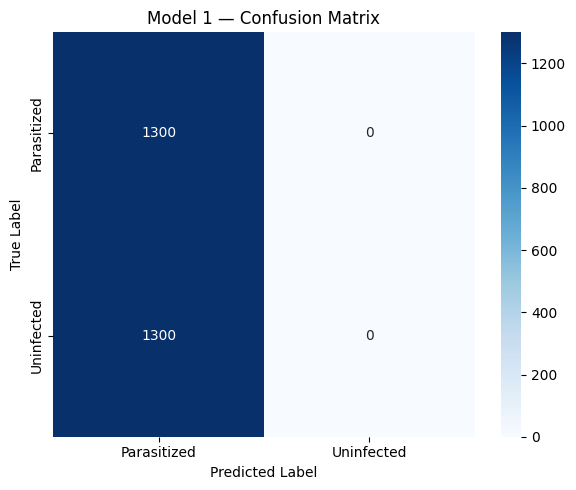

**Classification Report — Model 1 — Confusion Matrix**

| Class | Precision | Recall | F1-score | Support |
| --- | --- | --- | --- | --- |
| Parasitized | `0.500` | `1.000` | `0.667` | 1300 |
| Uninfected | `0.000` | `0.000` | `0.000` | 1300 |

| **Overall Accuracy** | | | **`0.500`** | 2600 |

```python
# Plot Model 1's confusion matrix on the held-out test set.
# `plot_confusion_matrix` is a helper defined earlier that:
#   1. runs `model.predict()` on `on_data`,
#   2. converts softmax probabilities to predicted class indices,
#   3. compares them with the true integer labels in `true_labels`,
#   4. renders the resulting matrix with a heatmap and axis labels.
plot_confusion_matrix(model1, on_data=test_images_norm, true_labels=test_labels, titled='Model 1 — Confusion Matrix')
```

**Not sure what happened here ❗️**

Will not try ti fix here, but it is definetely worth following.

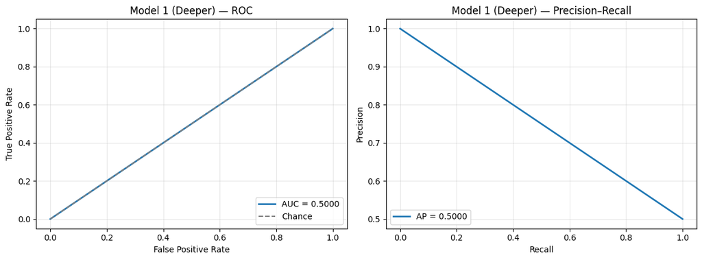

**Model 1 (Deeper)** — ROC AUC: `0.5000`, Average Precision: `0.5000`

```
(0.5, 0.5)
```

```python
# ROC + Precision-Recall for Model 1 (Deeper) (in-memory NumPy data path).
plot_roc_pr_keras(model1, on_data=test_images_norm, true_labels=test_labels,
                  titled='Model 1 (Deeper)')
```

### Plotting Train and Validation Curves

The most informative diagnostic for a CNN is the *training history* plot: training loss/accuracy vs validation loss/accuracy across epochs.

**How to read these curves:**

- If train and validation accuracy both rise together → healthy learning.
- If train accuracy keeps climbing while validation accuracy plateaus or *drops* → **overfitting**: the model is memorising the training set.
- If both curves stay flat at a low value → **underfitting**: the model lacks capacity or training time.
- If validation loss keeps oscillating wildly → the learning rate may be too high, or the validation set may be too small.

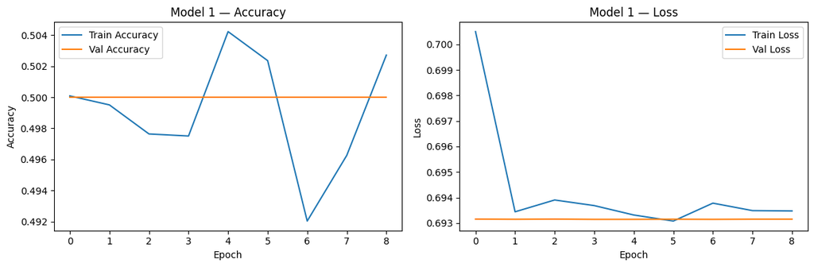

**Training summary — Model 1**

| Metric | Value |
| --- | --- |
| Best val accuracy | `0.5000` |
| Best val loss | `0.6931` |
| Final train acc | `0.5027` |
| Train / val gap | `0.0027` — ✅ well generalised |
| Total epochs run | `9` |

```python
# Plot Model 1's training history. `plot_history` is a helper that
# accepts a Keras `History` object and draws train+val accuracy and
# train+val loss curves side by side, with the title prefixed by
# `titled` so the figure is self-describing.
plot_history(history1, titled='Model 1')
```

## Model 2 — Batch Normalization + LeakyReLU

Model 2 keeps the three-block spatial path but simplifies back to **one Conv per block**. The novelty is inserting **BatchNormalization + LeakyReLU** between each Conv and the following MaxPool — shown stacked on each Conv node below.

**What is Batch Normalization (BN)?** Imagine you are training a deep network and the activations flowing through layer 5 keep drifting in scale during training (sometimes huge, sometimes tiny). This phenomenon is called *internal covariate shift* and it makes training slow and brittle. BN fixes it by, for each mini-batch, rescaling the activations to have approximately zero mean and unit variance, then learning two parameters per channel that re-scale and re-shift the result. The net effect: faster convergence, the ability to use higher learning rates, and a mild regularising effect.

**What is LeakyReLU?** Plain ReLU outputs 0 for any negative input. If a neuron's pre-activation is consistently negative, its gradient is also always 0 → it never updates → it is *dead*. LeakyReLU outputs `alpha * x` for `x < 0` instead of 0, leaving a small non-zero slope so gradients can still flow and the neuron can recover.

**Why use BOTH?** BN tames the activation distributions and LeakyReLU keeps neurons alive — they address different failure modes and play well together.

```
flowchart LR
    I["Input
(IMG_SIZE, IMG_SIZE, 3)"]:::input
    C1["Conv2D 32
+ BN + LeakyReLU(0.1)
(IMG_SIZE, IMG_SIZE, 32)"]:::conv
    P1["MaxPool 2x2
(IMG_SIZE/2, IMG_SIZE/2, 32)"]:::pool
    C2["Conv2D 64
+ BN + LeakyReLU(0.1)
(IMG_SIZE/2, IMG_SIZE/2, 64)"]:::conv
    P2["MaxPool 2x2
+ Dropout 0.25
(IMG_SIZE/4, IMG_SIZE/4, 64)"]:::pool
    C3["Conv2D 128
+ BN + LeakyReLU(0.1)
(IMG_SIZE/4, IMG_SIZE/4, 128)"]:::conv
    P3["MaxPool 2x2
+ Dropout 0.25
(IMG_SIZE/8, IMG_SIZE/8, 128)"]:::pool
    F["Flatten
(IMG_SIZE/8)² × 128"]:::flat
    D1["Dense 256
+ BN + LeakyReLU(0.1)
+ Dropout 0.5"]:::dense
    O["Dense 2
Softmax"]:::output

    I --> C1 --> P1 --> C2 --> P2 --> C3 --> P3 --> F --> D1 --> O

    classDef input  fill:#e3f2fd,stroke:#1565c0,stroke-width:2px,color:#000
    classDef conv   fill:#fff3e0,stroke:#e65100,stroke-width:2px,color:#000
    classDef pool   fill:#f3e5f5,stroke:#6a1b9a,stroke-width:2px,color:#000
    classDef dense  fill:#e8f5e9,stroke:#2e7d32,stroke-width:2px,color:#000
    classDef output fill:#ffebee,stroke:#b71c1c,stroke-width:3px,color:#000
    classDef flat   fill:#fafafa,stroke:#424242,stroke-width:2px,color:#000
```

Note the layer ordering: **Conv → BatchNorm → LeakyReLU → Pool**. BN operates on the raw pre-activation distribution; the activation function then applies non-linearity to the normalised output. BN is also applied inside the Dense head — not just the Conv stack.

**Why this exact order?** The original BN paper recommends applying BN to the *pre-activation* (the raw linear output of Conv or Dense, before any non-linearity). Otherwise BN would normalise a distribution that has already been clipped at zero by ReLU/LeakyReLU — that distribution is asymmetric and not well-described by mean and variance alone, so the normalisation would be less effective.

**Pooling vs Dropout placement.** Notice Dropout starts in Block 2, not Block 1. Early features are simple and high-information — dropping them out early can hurt convergence. Later blocks have more redundancy, so Dropout helps regularise without too much information loss.